# Lab2

Revina Polina

April 12, 2020

```r
library(foreign)
library(psych)
library(MASS)
library(VGAM)
library(ordinal)
library(brant)
library(lmtest)
library(generalhoslem)
library(pscl)
library(erer)
library(glm.predict)
library(aod)
```

```r
library(ggplot2)
library(dplyr)
library(memisc)
```

**Задание 1**

Загрузим данные и выберем нужные переменные:

```r
getwd()
```

```
## [1] "C:/Users/Polina/Desktop"
```

```r
lab2 <- read.dta("CDA_Lab4_2.dta")
lab2 <- dplyr::select(lab2, prioInt, p, f, gini, gdp, pop, mount, ncont, prioIntLag)
lab2$prioInt <- ordered(lab2$prioInt, levels = c(0,1,2), labels = c("peace", "weak", "strong"))
describe(lab2)
```

```
##            vars    n  mean    sd median trimmed   mad   min   max range
## prioInt*      1 1454  1.32  0.63   1.00    1.16  0.00  1.00  3.00  2.00
## p             2 1290  0.05  0.05   0.02    0.04  0.03  0.00  0.25  0.25
## f             3 1290  0.42  0.24   0.46    0.42  0.28  0.00  0.84  0.84
## gini          4 1289  0.04  0.13   0.01    0.02  0.01  0.00  1.77  1.77
## gdp           5 1294  7.98  1.11   7.99    7.96  1.42  5.38 10.33  4.95
## pop           6 1432 15.72  1.81  15.82   15.78  1.56 10.20 20.99 10.78
## mount         7 1437 15.52 19.85   8.50   11.46 12.60  0.00 82.20 82.20
## ncont         8 1454  0.15  0.35   0.00    0.06  0.00  0.00  1.00  1.00
## prioIntLag    9 1293  0.33  0.64   0.00    0.17  0.00  0.00  2.00  2.00
##             skew kurtosis   se
## prioInt*    1.77     1.75 0.02
## p           1.46     1.37 0.00
## f          -0.15    -1.13 0.01
## gini        6.92    62.25 0.00
## gdp         0.11    -1.07 0.03
## pop        -0.21     0.30 0.05
## mount       1.57     1.73 0.52
## ncont       2.01     2.02 0.01
## prioIntLag  1.73     1.60 0.02
```

```r
lab2 <- na.omit(lab2)
lab2$prev_conf_1 <- ifelse(lab2$prioIntLag == 0, 1, 0)
lab2$prev_conf_2 <- ifelse(lab2$prioIntLag == 1, 1, 0)
lab2$prev_conf_3 <- ifelse(lab2$prioIntLag == 2, 1, 0)
```

Оценим модель регресси:

```r
ologit.polr <- polr(prioInt ~ p + f + gini + gdp + pop + mount + ncont + prev_conf_2 + prev_conf_3, Hess=TRUE,
                    data=lab2, method="logistic")
```

Интерпретация оценок модели в терминах **отношения шансов**:

```r
exp(coef(ologit.polr))
```

```
##            p            f         gini          gdp          pop
## 6.966300e+02 3.222384e+00 6.463924e-03 6.503772e-01 1.095507e+00
##        mount        ncont  prev_conf_2  prev_conf_3
## 1.003935e+00 1.676987e+00 1.040364e+01 4.601557e+01
```

**p**: при увеличении уровня поляризации на 1 при прочих равных условиях шансы попасть в категорию сильного конфликта по сравнению со всеми остальными увеличиваются в 697 раз

**f**: при увеличении уровня фракционализации на 1 при прочих равных условиях шансы попасть в категорию сильного конфликта по сравнению со всеми остальными увеличиваются в 3.2 раз

**gini**: при увеличении индекса gini на 1 при прочих равных условиях шансы попасть в категориюю сильного конфликта по сравнению со всеми остальными уменьшаются в 0.006 раз

**gdp**: при увеличении логарифмированного показателя ВВП на 1 при прочих равных условиях шансы попасть в категорию сильного конфликта по сравнению со всеми остальными уменьшаются в 0.65 раз

**pop**: при увеличении логарифмированного показателя численности населения на 1 при прочих равных условиях шансы попасть в категорию сильного конфликта по сравнению со всеми остальными увеличиваются в 1.095 раз

**mount**: при увеличении процента горной местности на 1 при прочих равных условиях шансы попасть в категориюю сильного конфликта по сравению со всеми остальными увеличиваются в 1.0039 раз

**ncont**: при переходе от Noncontiguous states = 0 к Noncontiguous states = 1 при прочих равных условиях шансы попасть в категорию сильного конфликта по сравнению со всеми остальными увеличиваеются в 1.676 раз

**prev_conf_2**: при переходе от отсутствия конфликта в предыдущем периоде к наличию умеренного конфликта в предыдущем периоде при прочих равных условиях шансы попасть в категорию сильного конфликта по сравнению со всеми остальными увеличиваются в 10.403 раз

**prev_conf_3**: при переходе от умеренного конфликта в предыдущем периоде к наличию сильного конфликта в предыдущем периоде при прочих равных условиях шансы попасть в категорию сильного конфликта по сравнению со всеми остальными увеличиваются в 46.015 раз

Интерпретация на основе **дискретных изменений в предсказанных вероятностях**.

- 1. Зафиксируем показатели непрерывных переменных на уровне средних, для дамми-переменных определим следующее: ncont = 0 и ncont = 1, наличие умеренного конфликта в предыдущем периоде.

```r
dc(ologit.polr, values1 = c(mean(lab2$p), mean(lab2$f), mean(lab2$gini), mean(lab2$gdp), mean(lab2$pop), mean(lab2$mount),
0, 1, 0), values2 = c(mean(lab2$p), mean(lab2$f), mean(lab2$gini), mean(lab2$gdp), mean(lab2$pop), mean(lab2$mount),
1, 1, 0))
```

```
## [1]  0.04445781  0.41600195  0.03205987  8.02211721 16.18746480 16.90205478
## [7]  0.00000000  1.00000000  0.00000000
```

```
##            Mean1     1:2.5%   1:97.5%     Mean2    2:2.5%   2:97.5%
## peace  0.4826559 0.40084704 0.5644552 0.3589948 0.2536916 0.4890078
## weak   0.3961589 0.33026997 0.4585958 0.4518547 0.3797845 0.5110975
## strong 0.1211852 0.08676914 0.1647008 0.1891505 0.1229868 0.2675671
##          Mean.Diff    diff:2.5%  diff:97.5%
## peace   0.12366115 -0.007394307 0.230728011
## weak   -0.05569583 -0.106548214 0.004298509
## strong -0.06796532 -0.145139917 0.003095798
```

Итак, доверительный интервал для разницы накрывает ноль для всех категорий, поэтому дискретное изменение вероятности при переходе к Noncontiguous states = 1 статистически незначимо для той или иной степени конфликта.

- 2. Рассмотрим размах переменной – логарифм ВВП, остальные показатели непрерывных переменных зафиксируем на уровне средних, для дамми-переменных определим следующее: ncount = 1, наличие умеренного конфликта в предыдущем периоде.

```r
dc(ologit.polr, values1 = c(mean(lab2$p), mean(lab2$f), mean(lab2$gini), min(lab2$gdp), mean(lab2$pop), mean(lab2$mount),
1, 1, 0), values2 = c(mean(lab2$p), mean(lab2$f), mean(lab2$gini), max(lab2$gdp), mean(lab2$pop), mean(lab2$mount),
1, 1, 0))
```

```
## [1]  0.04445781  0.41600195  0.03205987  5.38300514 16.18746480 16.90205478
## [7]  1.00000000  1.00000000  0.00000000
```

```
##            Mean1     1:2.5%   1:97.5%      Mean2     2:2.5%   2:97.5%
## peace  0.1594104 0.07695846 0.2769070 0.60081910 0.46567168 0.7283658
## weak   0.4226253 0.31602566 0.5046613 0.31831032 0.22129563 0.4167462
## strong 0.4179643 0.24521210 0.6014051 0.08087058 0.04479667 0.1391167
##         Mean.Diff   diff:2.5% diff:97.5%
## peace  -0.4414087 -0.59079384 -0.2760304
## weak    0.1043150 -0.02983009  0.2235991
## strong  0.3370937  0.16455213  0.5175770
```

Интерпретация на основе **стандартизированных коэффициентов**.

```r
coef <- ologit.polr$coefficients
predictor <- labels(ologit.polr$coefficients)
predictor
```

```
## [1] "p"           "f"           "gini"        "gdp"         "pop"
## [6] "mount"       "ncont"       "prev_conf_2" "prev_conf_3"
```

```r
SDofX <- c(sd(lab2$p), sd(lab2$f), sd(lab2$gini), sd(lab2$gdp), sd(lab2$pop), sd(lab2$mount), NA, NA, NA)
SDofX
```

```
## [1]  0.05248565  0.24689324  0.09314287  1.11877710  1.43682830 20.49401361
## [7]          NA          NA          NA
```

```r
SDofLatentY <- sqrt(var(ologit.polr$lp) + ((pi^2)/3))
SDofLatentY
```

```
## [1] 2.61206
```

```r
std_data <- data.frame(predictor = predictor, coef= coef, SDofX = SDofX, OR = exp(coef), SD_OR = exp(coef*SDofX),
                       coef_StdY = coef/SDofLatentY, coef_StdXY = (coef*SDofX)/SDofLatentY)
std_data
```

```
##               predictor         coef       SDofX           OR     SD_OR
## p                     p  6.546254401  0.05248565 6.966300e+02 1.4099925
## f                     f  1.170121474  0.24689324 3.222384e+00 1.3349517
## gini               gini -5.041518716  0.09314287 6.463924e-03 0.6252639
## gdp                 gdp -0.430202763  1.11877710 6.503772e-01 0.6179789
## pop                 pop  0.091216866  1.43682830 1.095507e+00 1.1400396
## mount             mount  0.003927688 20.49401361 1.003935e+00 1.0838224
## ncont             ncont  0.516998625          NA 1.676987e+00        NA
## prev_conf_2 prev_conf_2  2.342155530          NA 1.040364e+01        NA
## prev_conf_3 prev_conf_3  3.828979871          NA 4.601557e+01        NA
##                coef_StdY  coef_StdXY
## p            2.506164954  0.13153769
## f            0.447968755  0.11060046
## gini        -1.930092653 -0.17977436
## gdp         -0.164698623 -0.18426105
## pop          0.034921422  0.05017609
## mount        0.001503674  0.03081632
## ncont        0.197927510          NA
## prev_conf_2  0.896669721          NA
## prev_conf_3  1.465884852          NA
```

**Cтандартизированные значения отношения шансов**: p: шансы попасть в категорию сильного конфликта увеличатся в 1.409 раз по сравнению со всеми остальными категориями при увеличении поляризации на одно стандартное отклонение

f: шансы попасть в категорию сильного конфликта увеличатся в 1.33 раз по сравнению со всеми остальными категориями при увеличении фракционализации на одно стандартное отклонение

gini: шансы попасть в категорию сильного конфликта уменьшатся в 0.625 раз по сравнению со всеми остальными категориями при увеличении gini на одно стандартное отклонение

gdp: шансы попасть в категорию сильного конфликта уменьшатся в 0.617 раз по сравнению со всеми остальными категориями при увеличении логарифма показателя ВВП на одно стандартное отклонение

pop: шансы попасть в категорию сильного конфликта увеличатся в 1.14 раз по сравнению со всеми остальными категориями при увеличении логарифма показателя населения на одно стандартное отклонение

mount: шансы попасть в категорию сильного конфликта увеличатся в 1.083 раз по сравнению со всеми остальными категориями при увеличении процента горных территорий на одно стандартное отклонение

**Частично стандартизованные коэффициенты**: p: при увеличении поляризации на 1 на 2.506 стандартных отклонений увеличится значение латетной зависимой переменной (склонность попасть в категорию сильного конфликта) при прочих равных условиях

f: при увеличении фракционализации на 1 на 0.447 стандартных отклонений увеличится значение латетной зависимой переменной (склонность попасть в категорию сильного конфликта) при прочих равных условиях

gini: при увеличении gini на 1 на 1.93 стандартных отклонений уменьшится значение латетной зависимой переменной (склонность попасть в категорию сильного конфликта) при прочих равных условиях

gdp: при увеличении gpd на 1 на 0.164 стандартных отклонений уменьшится значение латетной зависимой переменной (склонность попасть в категорию сильного конфликта) при прочих равных условиях

pop: при увеличении pop на 1 на 0.034 стандартных отклонений увеличится значение латетной зависимой переменной (склонность попасть в категорию сильного конфликта) при прочих равных условиях

mout: при увеличении mount на 1 на 0.001 стандартных отклонений увеличится значение латетной зависимой переменной (склонность попасть в категорию сильного конфликта) при прочих равных условиях

ncont: при переходе к ncont = 1 на 0.197 стандартных отклонений увеличится значение латетной зависимой переменной (склонность попасть в категорию сильного конфликта) при прочих равных условиях

prev_conf_2: при переходе от отсутствия конфликта в предыдущем периоде к наличию умеренного конфликта в предыдущем периоде на 0.896 стандартных отклонений увеличится значение латетной зависимой переменной (склонность попасть в категорию сильного конфликта) при прочих равных условиях

prev_conf_3: при переходе от умеренного конфликта в предыдущем периоде к сильному конфликту в предыдущем периоде на 1.465 стандартных отклонений увеличится значение латетной зависимой переменной (склонность попасть в категорию сильного конфликта) при прочих равных условиях

**Полностью стандартизованные коэффициенты**: p: при увеличении поляризации на одно стандартное отклонение на 0.131 увеличивается значение латентной зависимой переменной (склонность попасть в категорию сильного конфликта) при прочих равных

f: при увеличении фракционализации на одно стандартное отклонение на 0.11 увеличивается значение латентной зависимой переменной (склонность попасть в категорию сильного конфликта) при прочих равных

gini: при увеличении gini на одно стандартное отклонение на 0.179 уменьшается значение латентной зависимой переменной (склонность попасть в категорию сильного конфликта) при прочих равных

gdp: при увеличении gdp на одно стандартное отклонение на 0.184 уменьшается значение латентной зависимой переменной (склонность попасть в категорию сильного конфликта) при прочих равных

pop: при увеличении pop на одно стандартное отклонение на 0.05 увеличивается значение латентной зависимой переменной (склонность попасть в категорию сильного конфликта) при прочих равных

mount: при увеличении mount на одно стандартное отклонение на 0.03 увеличивается значение латентной зависимой переменной (склонность попасть в категорию сильного конфликта) при прочих равных

Интерпретация на основе **предельных эффектов**

Это релевантно только для непрерывных предикторов.

```r
ocME(ologit.polr)
```

```
##             effect.peace effect.weak effect.strong
## p                 -1.032       0.840         0.192
## f                 -0.185       0.150         0.034
## gini               0.795      -0.647        -0.148
## gdp                0.068      -0.055        -0.013
## pop               -0.014       0.012         0.003
## mount             -0.001       0.001         0.000
## ncont             -0.090       0.072         0.018
## prev_conf_2       -0.493       0.330         0.162
## prev_conf_3       -0.742       0.275         0.467
```

Посмотрим на значимость предельных эффектов:

```r
ocME(ologit.polr)$out
```

```
## $ME.peace
##             effect error t.value p.value
## p           -1.032 0.265  -3.892   0.000
## f           -0.185 0.063  -2.919   0.004
## gini         0.795 0.459   1.733   0.083
## gdp          0.068 0.015   4.651   0.000
## pop         -0.014 0.013  -1.135   0.256
## mount       -0.001 0.001  -0.977   0.329
## ncont       -0.090 0.049  -1.825   0.068
## prev_conf_2 -0.493 0.040 -12.184   0.000
## prev_conf_3 -0.742 0.028 -26.909   0.000
##
## $ME.weak
##             effect error t.value p.value
## p            0.840 0.220   3.813   0.000
## f            0.150 0.052   2.891   0.004
## gini        -0.647 0.376  -1.723   0.085
## gdp         -0.055 0.012  -4.529   0.000
## pop          0.012 0.010   1.134   0.257
## mount        0.001 0.001   0.975   0.330
## ncont        0.072 0.039   1.851   0.064
## prev_conf_2  0.330 0.028  11.862   0.000
## prev_conf_3  0.275 0.038   7.265   0.000
##
## $ME.strong
##             effect error t.value p.value
## p            0.192 0.053   3.625   0.000
## f            0.034 0.012   2.779   0.006
## gini        -0.148 0.086  -1.719   0.086
## gdp         -0.013 0.003  -4.177   0.000
## pop          0.003 0.002   1.125   0.261
## mount        0.000 0.000   0.971   0.332
## ncont        0.018 0.011   1.675   0.094
## prev_conf_2  0.162 0.026   6.224   0.000
## prev_conf_3  0.467 0.055   8.560   0.000
##
## $ME.all
##             effect.peace effect.weak effect.strong
## p                 -1.032       0.840         0.192
## f                 -0.185       0.150         0.034
## gini               0.795      -0.647        -0.148
## gdp                0.068      -0.055        -0.013
## pop               -0.014       0.012         0.003
## mount             -0.001       0.001         0.000
## ncont             -0.090       0.072         0.018
## prev_conf_2       -0.493       0.330         0.162
## prev_conf_3       -0.742       0.275         0.467
```

```r
# Для отсутствия конфликта не значимы статистически pop, mount
# Для умеренного конфликта не значимы статистически pop, mount
# Для сильного конфликта не значимы статистически pop, mount
```

**peace**: p: предсказанная вероятность отсутсвия конфликта изменится на -1.032 при увеличении поляризации на 1 и при всех остальных переменных зафиксированных на средних значениях

f: предсказанная вероятность отсутсвия конфликта изменится на -0.185 при увеличении фракционализации на 1 и при всех остальных переменных зафиксированных на средних значениях

gini: предсказанная вероятность отсутсвия конфликта изменится на 0.795 при увеличении gini на 1 и при всех остальных переменных зафиксированных на средних значениях

gdp: предсказанная вероятность отсутсвия конфликта изменится на 0.068 при увеличении gdp на 1 и при всех остальных переменных зафиксированных на средних значениях

**weak**: p: предсказанная вероятность умеренного конфликта изменится на 0.840 при увеличении поляризации на 1 и при всех остальных переменных зафиксированных на средних значениях

f: предсказанная вероятность умеренного конфликта изменится на 0.150 при увеличении фракционализации на 1 и при всех остальных переменных зафиксированных на средних значениях

gini: предсказанная вероятность умеренного конфликта изменится на -0.647 при увеличении gini на 1 и при всех остальных переменных зафиксированных на средних значениях

gdp: предсказанная вероятность умеренного конфликта изменится на -0.055 при увеличении gdp на 1 и при всех остальных переменных зафиксированных на средних значениях

**strong**: p: предсказанная вероятность сильного конфликта изменится на 0.192 при увеличении поляризации на 1 и при всех остальных переменных зафиксированных на средних значениях

f: предсказанная вероятность сильного конфликта изменится на 0.034 при увеличении фракционализации на 1 и при всех остальных переменных зафиксированных на средних значениях

gini: предсказанная вероятность сильного конфликта изменится на -0.148 при увеличении gini на 1 и при всех остальных переменных зафиксированных на средних значениях

gdp: предсказанная вероятность сильного конфликта изменится на -0.013 при увеличении gdp на 1 и при всех остальных переменных зафиксированных на средних значениях

**Задание 2**

```r
lab <- read.dta("new.dta")
head(lab)
```

[output not shown]

[output cut: 993 more lines]

```r
lab0 <- dplyr::select(lab, q304c, respondentage, q712, q310, q311)
lab0$q310 <- as.character(lab0$q310)
lab0$q310[lab0$q310 == "Refused"] <- NA
lab0$q310[lab0$q310 == "Not applicable"] <- NA
lab0$q310[lab0$q310 == "Don't know"] <- NA
lab0$q310[lab0$q310 == "Not stated"] <- NA
lab0$q310 <- as.factor(lab0$q310)
levels(lab0$q310) <- c("market", "planned", "organised")

lab0$q311 <- as.character(lab0$q311)
lab0$q311[lab0$q311 == "Refused"] <- NA
lab0$q311[lab0$q311 == "Not applicable"] <- NA
lab0$q311[lab0$q311 == "Don't know"] <- NA
lab0$q311[lab0$q311 == "Not stated"] <- NA
lab0$q311<- as.factor(lab0$q311)
levels(lab0$q311) <- c("democracy", "authoritarian", "not matter")

lab0$q712 <- as.character(lab0$q712)
lab0$q712[lab0$q712 == "Refused"] <- NA
lab0$q712[lab0$q712 == "Not applicable"] <- NA
lab0$q712[lab0$q712 == "Don't know"] <- NA
lab0$q712[lab0$q712 == "Not stated"] <- NA
lab0$q712[lab0$q712 == "Filtered"] <- NA
lab0$q712<- as.factor(lab0$q712)

lab0$q304c <- as.character(lab0$q304c)
lab0$q304c[lab0$q304c == "Don't know"] <- NA
lab0$q304c[lab0$q304c == "Refused"] <- NA
lab0$q304c[lab0$q304c == "6. Not applicable"] <- NA
lab0$q304c[lab0$q304c == "Filtered"] <- NA
lab0$q304c[lab0$q304c == "Not stated"] <- NA
lab0$q304c<- as.factor(lab0$q304c)

lab0 <- na.omit(lab0)
```

**Предикторы:** **respondentage** = respondent’s age **q712** = Are you currently a member of a political party? (1 - *yes*, 2 - *no*) **q310** = 1 - *A market economy is preferable to any other form of economic system*; 2 - *Under some circumstances, a planned economy may be preferable to a market economy*; 3 - *For people like me, it does not matter whether the economic system is organised as a market economy or as a planned economy*. **q311** = 1 - *Democracy is preferable to any other form of political system*; 2 - *Under some circumstances, an authoritarian government may be preferable to a democratic one*; 3 - *For people like me, it does not matter whether a government is democratic or authoritarian*.

Описательные статистики:

```r
summary(lab0)
```

```
##                            q304c       respondentage   q712
##  1. Complete distrust         : 5176   Min.   :-1.0   No :28702
##  2. Some distrust             : 7484   1st Qu.:31.0   Yes: 1934
##  3. Neither trust nor distrust:10760   Median :44.0
##  4. Some trust                : 6233   Mean   :45.5
##  5. Complete trust            :  983   3rd Qu.:58.0
##                                        Max.   :99.0
##         q310                  q311
##  market   :12782   democracy    :17613
##  planned  : 8890   authoritarian: 7132
##  organised: 8964   not matter   : 5891
##
##
##
```

Распределение зависимой переменной (наполняемость категорий):

```r
obs <- table(lab0$q304c)
cbind(obs, prop = prop.table(obs))
```

```
##                                 obs       prop
## 1. Complete distrust           5176 0.16895156
## 2. Some distrust               7484 0.24428777
## 3. Neither trust nor distrust 10760 0.35122079
## 4. Some trust                  6233 0.20345345
## 5. Complete trust               983 0.03208643
```

Отобразим наполняемость категорий на графике:

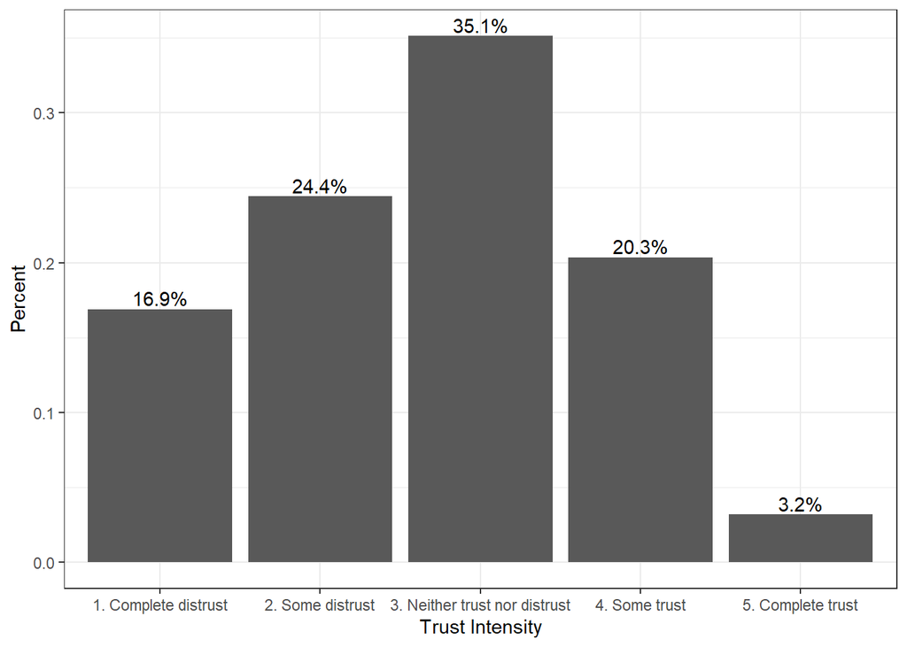

```r
ggplot(lab0, aes(x=q304c)) + geom_bar(aes(y = (..count..)/sum(..count..))) +
  geom_text(aes(y = ((..count..)/sum(..count..)), label = scales::percent((..count..)/sum(..count..))), stat = "count", vjust = -0.25) +
  theme_bw() + labs(y = 'Percent', x = 'Trust Intensity')
```

Как мы видим, наполняемость последней категории – “полное доверие” крайне невелико, в данном случае не будем объединять категории, чтобы не потерять в содержательной интерпретации.

Оценим модель с порядковым откликом, основанную на допущении о параллельности регрессий:

```r
ologit.polr <- polr(q304c ~ respondentage + q712 + q310 + q311, Hess=TRUE,
                    data=lab0, method="logistic")
summary(ologit.polr)
```

```
## Call:
## polr(formula = q304c ~ respondentage + q712 + q310 + q311, data = lab0,
##     Hess = TRUE, method = "logistic")
##
## Coefficients:
##                      Value Std. Error  t value
## respondentage      0.01053  0.0006106  17.2422
## q712Yes           -0.01592  0.0431324  -0.3691
## q310planned       -0.03784  0.0295753  -1.2795
## q310organised     -0.02981  0.0266396  -1.1189
## q311authoritarian -0.30666  0.0301597 -10.1678
## q311not matter    -0.15745  0.0287949  -5.4681
##
## Intercepts:
##                                                Value    Std. Error
## 1. Complete distrust|2. Some distrust           -1.2502   0.0329
## 2. Some distrust|3. Neither trust nor distrust   0.0045   0.0319
## 3. Neither trust nor distrust|4. Some trust      1.5481   0.0331
## 4. Some trust|5. Complete trust                  3.7858   0.0445
##                                                t value
## 1. Complete distrust|2. Some distrust          -37.9420
## 2. Some distrust|3. Neither trust nor distrust   0.1427
## 3. Neither trust nor distrust|4. Some trust     46.7721
## 4. Some trust|5. Complete trust                 84.9822
##
## Residual Deviance: 88193.67
## AIC: 88213.67
```

Оценка при помощи пакета ordinal.

```r
ologit.clm <- clm(q304c ~ respondentage + q712 + q310 + q311, data = lab0, link = "logit")
summary(ologit.clm)
```

```
## formula: q304c ~ respondentage + q712 + q310 + q311
## data:    lab0
##
##  link  threshold nobs  logLik    AIC      niter max.grad cond.H
##  logit flexible  30636 -44096.84 88213.67 6(0)  5.64e-09 9.9e+04
##
## Coefficients:
##                     Estimate Std. Error z value Pr(>|z|)
## respondentage      0.0105272  0.0006105  17.244  < 2e-16 ***
## q712Yes           -0.0159334  0.0431324  -0.369    0.712
## q310planned       -0.0378478  0.0295753  -1.280    0.201
## q310organised     -0.0298071  0.0266396  -1.119    0.263
## q311authoritarian -0.3066482  0.0301597 -10.167  < 2e-16 ***
## q311not matter    -0.1574508  0.0287949  -5.468 4.55e-08 ***
## ---
## Signif. codes:  0 '***' 0.001 '**' 0.01 '*' 0.05 '.' 0.1 ' ' 1
##
## Threshold coefficients:
##                                                 Estimate Std. Error
## 1. Complete distrust|2. Some distrust          -1.250168   0.032948
## 2. Some distrust|3. Neither trust nor distrust  0.004544   0.031858
## 3. Neither trust nor distrust|4. Some trust     1.548051   0.033096
## 4. Some trust|5. Complete trust                 3.785796   0.044546
##                                                z value
## 1. Complete distrust|2. Some distrust          -37.944
## 2. Some distrust|3. Neither trust nor distrust   0.143
## 3. Neither trust nor distrust|4. Some trust     46.774
## 4. Some trust|5. Complete trust                 84.987
```

Воспользуемся тестом Вальда для тестирования значимости коэффициентов. H0: B = 0

```r
wald.test(b = coef(ologit.clm), Sigma = vcov(ologit.clm), Terms = 5) # respondentage
```

```
## Wald test:
## ----------
##
## Chi-squared test:
## X2 = 297.4, df = 1, P(> X2) = 0.0
```

Pvalue < 0.05 => Есть основания для отвержения нулевой гипотезы в пользу альтернативы. Переменная respondentage статистически значимым образом отличается от нуля.

```r
wald.test(b = coef(ologit.clm), Sigma = vcov(ologit.clm), Terms = 6) # q712
```

```
## Wald test:
## ----------
##
## Chi-squared test:
## X2 = 0.14, df = 1, P(> X2) = 0.71
```

Pvalue > 0.05 => Нет оснований для отвержения нулевой гипотезы в пользу альтернативы. Переменная q712 статистически значимым образом не отличается от нуля.

Реализуем совместный тест Вальда.

```r
wald.test(b = coef(ologit.clm), Sigma = vcov(ologit.clm), Terms = 7:8) #q310
```

```
## Wald test:
## ----------
##
## Chi-squared test:
## X2 = 2.1, df = 2, P(> X2) = 0.36
```

Pvalue > 0.05 => Нет оснований для отвержения нулевой гипотезы в пользу альтернативы. Переменная q310 статистически значимым образом не отличается от нуля.

```r
wald.test(b = coef(ologit.clm), Sigma = vcov(ologit.clm), Terms = 9:10) #q311
```

```
## Wald test:
## ----------
##
## Chi-squared test:
## X2 = 111.3, df = 2, P(> X2) = 0.0
```

Pvalue < 0.05 => Есть основания для отвержения нулевой гипотезы в пользу альтернативы. Данные переменные статистически значимым образом отличаются от нуля, т.е. вносят значимый вклад в степень доверия.

Уточним спецификацию модели: удалим незначимую переменную.

```r
ologit.clm.nopr <- clm(q304c ~ respondentage + q311 + q310, data = lab0, link = "logit")
summary(ologit.clm.nopr)
```

```
## formula: q304c ~ respondentage + q311 + q310
## data:    lab0
##
##  link  threshold nobs  logLik    AIC      niter max.grad cond.H
##  logit flexible  30636 -44096.90 88211.81 6(0)  6.17e-09 9.7e+04
##
## Coefficients:
##                     Estimate Std. Error z value Pr(>|z|)
## respondentage      0.0105316  0.0006104  17.255  < 2e-16 ***
## q311authoritarian -0.3065218  0.0301575 -10.164  < 2e-16 ***
## q311not matter    -0.1573533  0.0287934  -5.465 4.63e-08 ***
## q310planned       -0.0374610  0.0295566  -1.267    0.205
## q310organised     -0.0297768  0.0266394  -1.118    0.264
## ---
## Signif. codes:  0 '***' 0.001 '**' 0.01 '*' 0.05 '.' 0.1 ' ' 1
##
## Threshold coefficients:
##                                                 Estimate Std. Error
## 1. Complete distrust|2. Some distrust          -1.248821   0.032745
## 2. Some distrust|3. Neither trust nor distrust  0.005874   0.031654
## 3. Neither trust nor distrust|4. Some trust     1.549391   0.032897
## 4. Some trust|5. Complete trust                 3.787158   0.044394
##                                                z value
## 1. Complete distrust|2. Some distrust          -38.138
## 2. Some distrust|3. Neither trust nor distrust   0.186
## 3. Neither trust nor distrust|4. Some trust     47.098
## 4. Some trust|5. Complete trust                 85.308
```

Сравним модели:

```r
lrtest(ologit.clm, ologit.clm.nopr)
```

```
## Likelihood ratio test
##
## Model 1: q304c ~ respondentage + q712 + q310 + q311
## Model 2: q304c ~ respondentage + q311 + q310
##   #Df LogLik Df  Chisq Pr(>Chisq)
## 1  10 -44097
## 2   9 -44097 -1 0.1365     0.7118
```

H0: нет статистически значимых различий между моделями. P-value > 0.05 => нет оснований для отвержения нулевой гипотезы в пользу альтернативы, следовательно, стоит предпочесть более экономную модель.

Проинтерпретируем результаты модели с уточненной спецификацией. Дополнительно оценим выбранную модель в другом пакете:

```r
ologit.no <- polr(q304c ~ respondentage + q311 + q310, data = lab0, Hess = TRUE, method="logistic")
summary(ologit.no)
```

```
## Call:
## polr(formula = q304c ~ respondentage + q311 + q310, data = lab0,
##     Hess = TRUE, method = "logistic")
##
## Coefficients:
##                      Value Std. Error t value
## respondentage      0.01053  0.0006104  17.253
## q311authoritarian -0.30652  0.0301576 -10.164
## q311not matter    -0.15736  0.0287935  -5.465
## q310planned       -0.03747  0.0295567  -1.268
## q310organised     -0.02978  0.0266395  -1.118
##
## Intercepts:
##                                                Value    Std. Error
## 1. Complete distrust|2. Some distrust           -1.2489   0.0327
## 2. Some distrust|3. Neither trust nor distrust   0.0059   0.0317
## 3. Neither trust nor distrust|4. Some trust      1.5494   0.0329
## 4. Some trust|5. Complete trust                  3.7871   0.0444
##                                                t value
## 1. Complete distrust|2. Some distrust          -38.1377
## 2. Some distrust|3. Neither trust nor distrust   0.1852
## 3. Neither trust nor distrust|4. Some trust     47.0949
## 4. Some trust|5. Complete trust                 85.3031
##
## Residual Deviance: 88193.81
## AIC: 88211.81
```

**Через отношения шансов:** (проинтерпретируем все коэффициенты в качестве выполнения задания)

```r
exp(coef(ologit.no))
```

```
##     respondentage q311authoritarian    q311not matter       q310planned
##         1.0105877         0.7360025         0.8544005         0.9632227
##     q310organised
##         0.9706543
```

**respondentage**: при увеличении возраста респондента на 1 при прочих равных условиях шансы попасть в категорию полного доверия по сравнению со всеми остальными увеличиваются в 1.01 раз

**q311authoritarian**: при переходе от категории предпочтения демократии к категории предпочтения автократии шансы попасть в категорию полного доверия по сравнению со всеми остальными уменьшаются в 0.736 раз

**q311not matter**: при переходе от категории предпочтения автократии к категории безразличия режима шансы попасть в категорию полного доверия по сравнению со всеми остальными уменьшаются в 0.854 раз

**q310planned**: при переходе от категории предпочтения рыночной экономики к категории предпочтения плановой экономики шансы попасть в категорию полного доверия по сравнению со всеми остальными уменьшаются в 0.963 раз

**q310organised***: при переходе от категории предпочтения плановой экономики к категории безразличия шансы попасть в категорию полного доверия по сравнению со всеми остальными уменьшаются в 0.97 раз

**Через стандартизированные коэффициенты:**

```r
coef <- ologit.no$coefficients
coef
```

```
##     respondentage q311authoritarian    q311not matter       q310planned
##        0.01053201       -0.30652176       -0.15735519       -0.03747067
##     q310organised
##       -0.02978494
```

```r
predictor <- labels(ologit.no$coefficients)
# поставим NA для категориальных переменных
SDofX <- c(sd(lab0$respondentage), NA, NA, NA, NA)
SDofLatentY <- sqrt(var(ologit.no$lp) + ((pi^2)/3))
SDofLatentY
```

```
## [1] 1.826614
```

```r
std_data <- data.frame(predictor = predictor, coef= coef, SDofX = SDofX, OR = exp(coef), SD_OR = exp(coef*SDofX),
                       coef_StdY = coef/SDofLatentY, coef_StdXY = (coef*SDofX)/SDofLatentY)
std_data
```

```
##                           predictor        coef    SDofX        OR
## respondentage         respondentage  0.01053201 17.08468 1.0105877
## q311authoritarian q311authoritarian -0.30652176       NA 0.7360025
## q311not matter       q311not matter -0.15735519       NA 0.8544005
## q310planned             q310planned -0.03747067       NA 0.9632227
## q310organised         q310organised -0.02978494       NA 0.9706543
##                      SD_OR    coef_StdY coef_StdXY
## respondentage     1.197141  0.005765867 0.09850799
## q311authoritarian       NA -0.167808696         NA
## q311not matter          NA -0.086145824         NA
## q310planned             NA -0.020513726         NA
## q310organised           NA -0.016306091         NA
```

**Cтандартизированные значения отношения шансов**: respondentage: шансы попасть в категорию полного согласия увеличатся в 1.197 раз по сравнению со всеми остальными категориями при увеличении возраста респондента на одно стандартное отклонение

**Частично стандартизованные коэффициенты**: respondentage: при увеличении возраста респондента на 1 на 0.0057 стандартных отклонений увеличится значение латентной зависимой переменной (склонность попасть в категорию полного согласия) при прочих равных условиях

q311authoritarian: при переходе от категории предпочтения демократии к предпочтению авторитаризма на -0.1678 стандартных отклонений уменьшится значение латентной зависимой переменной (склонность попасть в категорию полного согласия) при прочих равных условиях

q311not matter: при переходе от категории предпочтения авторитаризма к безразличию на -0.086 стандартных отклонений уменьшится значение латентной зависимой переменной (склонность попасть в категорию полного согласия) при прочих равных условиях

q310planned: при переходе от категории предпочтения рыночной экономики к плановой на -0.02051 стандартных отклонений уменьшится значение латентной зависимой переменной (склонность попасть в категорию полного согласия) при прочих равных условиях

q310organised: при переходе от категории предпочтения плановой экономики к безразличию на -0.0163 стандартных отклонений уменьшится значение латентной зависимой переменной (склонность попасть в категорию полного согласия) при прочих равных условиях

**Полностью стандартизованные коэффициенты**: respondentage: при увеличении возраста респондента на одно стандартное отклонение на 0.0985 увеличивается значение латентной зависимой переменной (склонность попасть в категорию полного согласия) при прочих равных условиях

**Через предельные эффекты:** Интерпретация через предельные эффекты значима только для непрерывных переменных, т.е. в данном случае только для возраста респондета.

```r
ocME(ologit.no)
```

```
##                   effect.1. Complete distrust effect.2. Some distrust
## respondentage                          -0.001                  -0.001
## q311authoritarian                       0.045                   0.030
## q311not matter                          0.023                   0.016
## q310planned                             0.005                   0.004
## q310organised                           0.004                   0.003
##                   effect.3. Neither trust nor distrust
## respondentage                                    0.001
## q311authoritarian                               -0.023
## q311not matter                                  -0.011
## q310planned                                     -0.002
## q310organised                                   -0.002
##                   effect.4. Some trust effect.5. Complete trust
## respondentage                    0.002                    0.000
## q311authoritarian               -0.044                   -0.009
## q311not matter                  -0.023                   -0.005
## q310planned                     -0.006                   -0.001
## q310organised                   -0.004                   -0.001
```

Рассмотрим значимость предельных эффектов: возраст значим для всех категорий

```r
ocME(ologit.no)$out
```

```
## $`ME.1. Complete distrust`
##                   effect error t.value p.value
## respondentage     -0.001 0.000 -17.126   0.000
## q311authoritarian  0.045 0.005   9.635   0.000
## q311not matter     0.023 0.004   5.295   0.000
## q310planned        0.005 0.004   1.261   0.207
## q310organised      0.004 0.004   1.113   0.266
##
## $`ME.2. Some distrust`
##                   effect error t.value p.value
## respondentage     -0.001 0.000 -16.734   0.000
## q311authoritarian  0.030 0.003  10.676   0.000
## q311not matter     0.016 0.003   5.613   0.000
## q310planned        0.004 0.003   1.273   0.203
## q310organised      0.003 0.003   1.121   0.262
##
## $`ME.3. Neither trust nor distrust`
##                   effect error t.value p.value
## respondentage      0.001 0.000  15.602   0.000
## q311authoritarian -0.023 0.003  -8.804   0.000
## q311not matter    -0.011 0.002  -4.987   0.000
## q310planned       -0.002 0.002  -1.247   0.212
## q310organised     -0.002 0.002  -1.103   0.270
##
## $`ME.4. Some trust`
##                   effect error t.value p.value
## respondentage      0.002 0.000  17.131   0.000
## q311authoritarian -0.044 0.004 -10.572   0.000
## q311not matter    -0.023 0.004  -5.590   0.000
## q310planned       -0.006 0.004  -1.272   0.203
## q310organised     -0.004 0.004  -1.121   0.262
##
## $`ME.5. Complete trust`
##                   effect error t.value p.value
## respondentage      0.000 0.000  15.527   0.000
## q311authoritarian -0.009 0.001 -10.440   0.000
## q311not matter    -0.005 0.001  -5.642   0.000
## q310planned       -0.001 0.001  -1.276   0.202
## q310organised     -0.001 0.001  -1.124   0.261
##
## $ME.all
##                   effect.1. Complete distrust effect.2. Some distrust
## respondentage                          -0.001                  -0.001
## q311authoritarian                       0.045                   0.030
## q311not matter                          0.023                   0.016
## q310planned                             0.005                   0.004
## q310organised                           0.004                   0.003
##                   effect.3. Neither trust nor distrust
## respondentage                                    0.001
## q311authoritarian                               -0.023
## q311not matter                                  -0.011
## q310planned                                     -0.002
## q310organised                                   -0.002
##                   effect.4. Some trust effect.5. Complete trust
## respondentage                    0.002                    0.000
## q311authoritarian               -0.044                   -0.009
## q311not matter                  -0.023                   -0.005
## q310planned                     -0.006                   -0.001
## q310organised                   -0.004                   -0.001
```

Complete distrust: предсказанная вероятность полного недоверия изменится на -0.001 при увеличении возраста респондента на 1 и при всех остальных переменных зафиксированных на средних значениях

Some distrust: предсказанная вероятность некоторого недоверия изменится на -0.001 при увеличении возраста респондента на 1 и при всех остальных переменных зафиксированных на средних значениях

Neither trust nor distrust: предсказанная вероятность ни доверия ни недоверия изменится на 0.001 при увеличении возраста респондента на 1 и при всех остальных переменных зафиксированных на средних значениях

Some trust: предсказанная вероятность некоторого доверия изменится на 0.002 при увеличении возраста респондента на 1 и при всех остальных переменных зафиксированных на средних значениях

Complete trust: предсказанная вероятность полного доверия изменится на 0.000 при увеличении возраста респондента на 1 и при всех остальных переменных зафиксированных на средних значениях

**Через дискретные изменения в вероятностях:** Зафиксируем показатель непрерывной переменной – возраста респондента, на среднем уровне, также зафиксируем следующее для дамми-переменных: (1) предпочтение авторитаризма и плановой экономики и (2) безразличие в выборе режима.

```r
dc(ologit.no, values1 = c(mean(lab0$respondentage), 1, 0, 1, 0), values2 = c(mean(lab0$respondentage), 0, 1, 0, 1))
```

```
## [1] 45.5014  1.0000  0.0000  1.0000  0.0000
```

```
##                                    Mean1     1:2.5%    1:97.5%      Mean2
## 1. Complete distrust          0.20060588 0.19292518 0.20831622 0.17654514
## 2. Some distrust              0.26730522 0.26124416 0.27315212 0.25244188
## 3. Neither trust nor distrust 0.33652541 0.33043696 0.34275940 0.34947900
## 4. Some trust                 0.17028286 0.16413813 0.17686782 0.19206695
## 5. Complete trust             0.02528064 0.02345636 0.02719875 0.02946703
##                                   2:2.5%    2:97.5%    Mean.Diff
## 1. Complete distrust          0.16917650 0.18479267  0.024060730
## 2. Some distrust              0.24574939 0.25901044  0.014863338
## 3. Neither trust nor distrust 0.34312660 0.35532754 -0.012953592
## 4. Some trust                 0.18442580 0.19971976 -0.021784087
## 5. Complete trust             0.02723567 0.03188801 -0.004186388
##                                  diff:2.5%   diff:97.5%
## 1. Complete distrust           0.013839911  0.034194192
## 2. Some distrust               0.008254099  0.021443180
## 3. Neither trust nor distrust -0.018381803 -0.007455146
## 4. Some trust                 -0.031269851 -0.012306065
## 5. Complete trust             -0.006058114 -0.002376658
```

Итак, доверительный интервал для разницы не накрывает ноль ни для одной из категорий доверия, следовательно, дискретное изменение вероятности при переходе от категории предпочтения авторитаризма к категории безразличия политического режима является значимым и влияет статистическим образом на вероятность той или иной степени доверия.

Проверим, насколько адекватна наша модель: реализуем **goodness-of-fit test (Hosmer-Lemeshow)** с поправкой на порядковый отклик.

H0: нет различий между предсказанными значениями вероятности и наблюдаемыми значениями в отдельных проранжированных подгруппах.

```r
logitgof(lab0$q304c, fitted(ologit.no), ord = TRUE)
```

```
##
##  Hosmer and Lemeshow test (ordinal model)
##
## data:  lab0$q304c, fitted(ologit.no)
## X-squared = 48.896, df = 35, p-value = 0.05955
```

Pvalue > 0.05 => Нет оснований для отвержения нулевой гипотезы в пользу альтернативы. Следовательно, в целом, модель хороша с точки зрания качества модели.

Построим *графики предсказанных вероятностей* для каждой категории доверия.

```r
pred <- round(predict(ologit.no, lab0, type = "prob"), 3)
head(pred)
```

```
##   1. Complete distrust 2. Some distrust 3. Neither trust nor distrust
## 2                0.198            0.266                         0.338
## 3                0.178            0.253                         0.349
## 4                0.145            0.228                         0.363
## 5                0.158            0.239                         0.358
## 6                0.200            0.267                         0.337
## 7                0.176            0.252                         0.350
##   4. Some trust 5. Complete trust
## 2         0.173             0.026
## 3         0.191             0.029
## 4         0.228             0.037
## 5         0.212             0.034
## 6         0.171             0.025
## 7         0.192             0.030
```

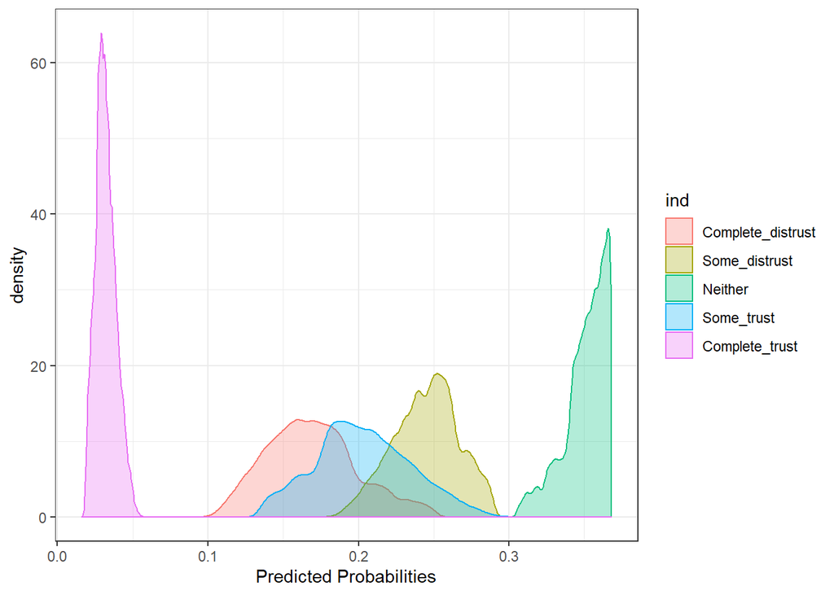

```r
pred.l <- list(Complete_distrust = pred[,1], Some_distrust = pred[,2], Neither = pred[,3], Some_trust = pred[,4], Complete_trust = pred[,5])
pred.stack <- stack(pred.l)
ggplot(pred.stack, aes(x=values)) +
  geom_density(aes(group=ind, colour=ind, fill=ind), alpha=0.3) +
  theme_bw() + labs(x='Predicted Probabilities')
```

Как мы видим, большая часть наблюдений имеет высокую вероятность попасть в категорию “ни доверие ни недоверие”, в то время как для категории “полное доверие” преобладают низкие вероятности.

Построим *графики зависимости предсказанных вероятностей попасть в ту или иную категорию отклика от непрерывного предиктора*: возраста респондента.

```r
pr.data.f <- data.frame(respondentage =seq(min(lab0$respondentage), max(lab0$respondentage), length.out = 100),
                        q311 = "democracy",
                        q310 = "market")
pr.f <- predict(ologit.clm.nopr, pr.data.f, type="prob")
head(pr.f)
```

```
## $fit
##     1. Complete distrust 2. Some distrust 3. Neither trust nor distrust
## 1             0.22473387        0.2793675                     0.3222409
## 2             0.22288586        0.2785561                     0.3233684
## 3             0.22104871        0.2777338                     0.3244855
## 4             0.21922243        0.2769006                     0.3255917
## 5             0.21740703        0.2760568                     0.3266871
## 6             0.21560251        0.2752025                     0.3277715
## 7             0.21380888        0.2743378                     0.3288446
## 8             0.21202613        0.2734629                     0.3299063
## 9             0.21025427        0.2725780                     0.3309565
## 10            0.20849331        0.2716831                     0.3319949
## 11            0.20674323        0.2707784                     0.3330214
## 12            0.20500403        0.2698641                     0.3340359
## 13            0.20327572        0.2689404                     0.3350381
```

[output cut: 188 more lines]

```r
pr.cum.f <- predict(ologit.clm.nopr, pr.data.f, type="cum.prob")
head(pr.cum.f$cprob1)
```

```
##   1. Complete distrust 2. Some distrust 3. Neither trust nor distrust
## 1            0.2247339        0.5041014                     0.8263423
## 2            0.2228859        0.5014420                     0.8248104
## 3            0.2210487        0.4987825                     0.8232679
## 4            0.2192224        0.4961230                     0.8217148
## 5            0.2174070        0.4934638                     0.8201510
## 6            0.2156025        0.4908050                     0.8185765
##   4. Some trust 5. Complete trust
## 1     0.9780692                 1
## 2     0.9778399                 1
## 3     0.9776082                 1
## 4     0.9773741                 1
## 5     0.9771377                 1
## 6     0.9768988                 1
```

```r
pr.data.f <- cbind(pr.data.f, pr.f)
colnames(pr.data.f)[4:8] <- c("prob.Complete_distrust", "prob.Some_distrust", "prob.Neither", "prob.Some_trust", "prob.Complete_trust")

pr.data.f <- cbind(pr.data.f, pr.cum.f$cprob1)
head(pr.data.f)
```

```
##   respondentage      q311   q310 prob.Complete_distrust prob.Some_distrust
## 1   -1.00000000 democracy market              0.2247339          0.2793675
## 2    0.01010101 democracy market              0.2228859          0.2785561
## 3    1.02020202 democracy market              0.2210487          0.2777338
## 4    2.03030303 democracy market              0.2192224          0.2769006
## 5    3.04040404 democracy market              0.2174070          0.2760568
## 6    4.05050505 democracy market              0.2156025          0.2752025
##   prob.Neither prob.Some_trust prob.Complete_trust 1. Complete distrust
## 1    0.3222409       0.1517270          0.02193078            0.2247339
## 2    0.3233684       0.1530295          0.02216012            0.2228859
## 3    0.3244855       0.1543403          0.02239181            0.2210487
## 4    0.3255917       0.1556593          0.02262587            0.2192224
## 5    0.3266871       0.1569867          0.02286232            0.2174070
## 6    0.3277715       0.1583223          0.02310118            0.2156025
##   2. Some distrust 3. Neither trust nor distrust 4. Some trust
## 1        0.5041014                     0.8263423     0.9780692
## 2        0.5014420                     0.8248104     0.9778399
## 3        0.4987825                     0.8232679     0.9776082
## 4        0.4961230                     0.8217148     0.9773741
## 5        0.4934638                     0.8201510     0.9771377
## 6        0.4908050                     0.8185765     0.9768988
##   5. Complete trust
## 1                 1
## 2                 1
## 3                 1
## 4                 1
## 5                 1
## 6                 1
```

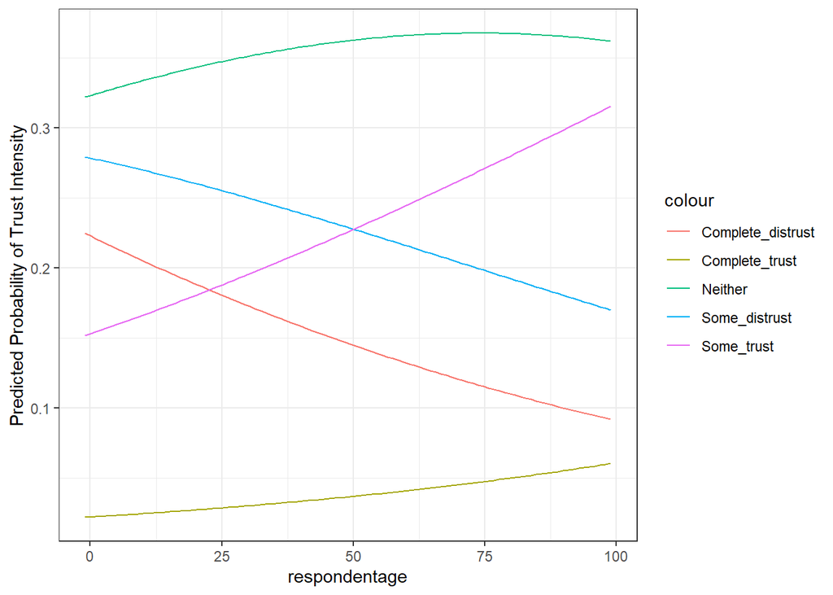

```r
colnames(pr.data.f)[9:13] <- c("cum.Complete_distrust", "cum.Some_distrust", "cum.Neither", "cum.Some_trust", "cum.Complete_trust")

ggplot(pr.data.f, aes(respondentage)) +
  geom_line(aes(y = prob.Complete_distrust, colour = "Complete_distrust")) +
  geom_line(aes(y = prob.Some_distrust, colour = "Some_distrust")) +
  geom_line(aes(y = prob.Neither, colour = "Neither")) +
  geom_line(aes(y = prob.Some_trust, colour = "Some_trust")) +
  geom_line(aes(y = prob.Complete_trust, colour = "Complete_trust")) +
  theme_bw() +
  labs(x='respondentage', y = 'Predicted Probability of Trust Intensity')
```

Итак, как мы видим, функциональная взаимосвязь близка к линейной, поэтому можно говорить об интерпретации в терминах предельного эффекта.

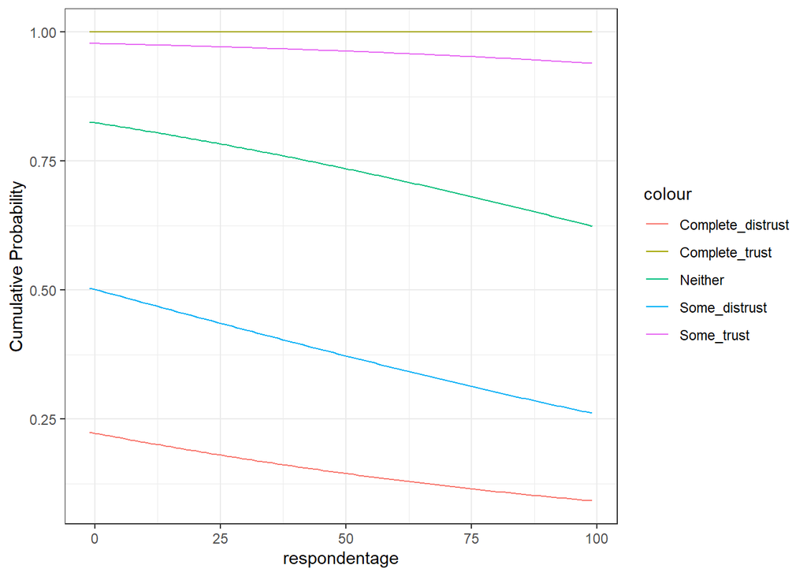

```r
ggplot(pr.data.f, aes(respondentage)) +
  geom_line(aes(y = cum.Complete_distrust, colour = "Complete_distrust")) +
  geom_line(aes(y = cum.Some_distrust, colour = "Some_distrust")) +
  geom_line(aes(y = cum.Neither, colour = "Neither")) +
  geom_line(aes(y = cum.Some_trust, colour = "Some_trust")) +
  geom_line(aes(y = cum.Complete_trust, colour = "Complete_trust")) +
  theme_bw() +
  labs(x='respondentage', y = 'Cumulative Probability')
```

```r
head(pr.data.f)
```

```
##   respondentage      q311   q310 prob.Complete_distrust prob.Some_distrust
## 1   -1.00000000 democracy market              0.2247339          0.2793675
## 2    0.01010101 democracy market              0.2228859          0.2785561
## 3    1.02020202 democracy market              0.2210487          0.2777338
## 4    2.03030303 democracy market              0.2192224          0.2769006
## 5    3.04040404 democracy market              0.2174070          0.2760568
## 6    4.05050505 democracy market              0.2156025          0.2752025
##   prob.Neither prob.Some_trust prob.Complete_trust cum.Complete_distrust
## 1    0.3222409       0.1517270          0.02193078             0.2247339
## 2    0.3233684       0.1530295          0.02216012             0.2228859
## 3    0.3244855       0.1543403          0.02239181             0.2210487
## 4    0.3255917       0.1556593          0.02262587             0.2192224
## 5    0.3266871       0.1569867          0.02286232             0.2174070
## 6    0.3277715       0.1583223          0.02310118             0.2156025
##   cum.Some_distrust cum.Neither cum.Some_trust cum.Complete_trust
## 1         0.5041014   0.8263423      0.9780692                  1
## 2         0.5014420   0.8248104      0.9778399                  1
## 3         0.4987825   0.8232679      0.9776082                  1
## 4         0.4961230   0.8217148      0.9773741                  1
## 5         0.4934638   0.8201510      0.9771377                  1
## 6         0.4908050   0.8185765      0.9768988                  1
```

Уменьшается вероятность попасть во все категории, кроме “полного доверия”.

Протестируем модель **пропорциональных шансов**. Посмотрим на оценки с бинарным откликом:

```r
table(as.numeric(lab0$q304c))
```

```
##
##     1     2     3     4     5
##  5176  7484 10760  6233   983
```

```r
lab0$q304c_1 <- ifelse(as.numeric(lab0$q304c) > 1, 0, 1)
lab0$q304c_2 <- ifelse(as.numeric(lab0$q304c) > 2, 0, 1)
lab0$q304c_3 <- ifelse(as.numeric(lab0$q304c) > 3, 0, 1)
lab0$q304c_4 <- ifelse(as.numeric(lab0$q304c) > 4, 0, 1)

logit1 <- glm(q304c_1 ~ respondentage + q311 + q310, data = lab0,
              family = binomial(link="logit"))
logit2 <- glm(q304c_2 ~ respondentage + q311 + q310, data = lab0,
              family = binomial(link="logit"))
logit3 <- glm(q304c_3 ~ respondentage + q311 + q310, data = lab0,
              family = binomial(link="logit"))
logit4 <- glm(q304c_4 ~ respondentage + q311 + q310, data = lab0,
              family = binomial(link="logit"))
mtable(logit1, logit2, logit3, logit4)
```

```
##
## Calls:
## logit1: glm(formula = q304c_1 ~ respondentage + q311 + q310, family = binomial(link = "logit"),
##     data = lab0)
## logit2: glm(formula = q304c_2 ~ respondentage + q311 + q310, family = binomial(link = "logit"),
##     data = lab0)
## logit3: glm(formula = q304c_3 ~ respondentage + q311 + q310, family = binomial(link = "logit"),
##     data = lab0)
## logit4: glm(formula = q304c_4 ~ respondentage + q311 + q310, family = binomial(link = "logit"),
##     data = lab0)
##
## ============================================================================================
##                                     logit1         logit2         logit3         logit4
##                                 -------------- -------------- -------------- -------------
##                                     q304c_1        q304c_2        q304c_3       q304c_4
## --------------------------------------------------------------------------------------------
##   (Intercept)                        -0.964***      -0.007          1.416***      3.452***
##                                      (0.045)        (0.035)        (0.041)       (0.097)
##   respondentage                      -0.015***      -0.010***      -0.009***     -0.005**
##                                      (0.001)        (0.001)        (0.001)       (0.002)
##   q311: authoritarian/democracy       0.323***       0.347***       0.248***      0.117
##                                      (0.044)        (0.034)        (0.040)       (0.099)
##   q311: not matter/democracy          0.034          0.173***       0.222***      0.124
##                                      (0.044)        (0.033)        (0.039)       (0.093)
##   q310: planned/market               -0.092*         0.018          0.127**       0.321***
##                                      (0.044)        (0.034)        (0.039)       (0.096)
##   q310: organised/market             -0.023          0.009          0.080*        0.169*
##                                      (0.040)        (0.030)        (0.035)       (0.083)
## --------------------------------------------------------------------------------------------
##   Log-likelihood                 -13749.461     -20594.024     -16615.756     -4332.782
##   N                               30636          30636          30636         30636
## ============================================================================================
##   Significance: *** = p < 0.001; ** = p < 0.01; * = p < 0.05
```

Как мы видим, в целом направление и значимость оценок коэффициентов не сохраняется.

Реализуем тест Бранта.

```r
brant(ologit.no)
```

```
## ----------------------------------------------------
## Test for     X2  df  probability
## ----------------------------------------------------
## Omnibus          115.94  15  0
## respondentage        52.9    3   0
## q311authoritarian    8.88    3   0.03
## q311not matter       16.62   3   0
## q310planned      23.56   3   0
## q310organised        7.43    3   0.06
## ----------------------------------------------------
##
## H0: Parallel Regression Assumption holds
```

```
##                           X2 df  probability
## Omnibus           115.936800 15 1.158469e-17
## respondentage      52.895324  3 1.930032e-11
## q311authoritarian   8.877516  3 3.096449e-02
## q311not matter     16.622085  3 8.451617e-04
## q310planned        23.564541  3 3.079450e-05
## q310organised       7.430400  3 5.937401e-02
```

Оценим спецификацию модели частично пропорциональных шансов:

```r
gologit_partial <- vglm(q304c_1 ~ respondentage + q311 + q310, family = cumulative(parallel = T~respondentage+q311-1), data = lab0)
summary(gologit_partial)
```

```
##
## Call:
## vglm(formula = q304c_1 ~ respondentage + q311 + q310, family = cumulative(parallel = T ~
##     respondentage + q311 - 1), data = lab0)
##
## Pearson residuals:
##                       Min     1Q Median     3Q    Max
## logitlink(P[Y<=1]) -3.562 0.3642 0.4261 0.4822 0.6467
##
## Coefficients:
##                     Estimate Std. Error z value Pr(>|z|)
## (Intercept)        0.9638093  0.0451638  21.340  < 2e-16 ***
## respondentage      0.0154657  0.0009356  16.529  < 2e-16 ***
## q311authoritarian -0.3234615  0.0440613  -7.341 2.12e-13 ***
## q311not matter    -0.0339805  0.0437843  -0.776   0.4377
## q310planned        0.0921695  0.0444608   2.073   0.0382 *
## q310organised      0.0234108  0.0398281   0.588   0.5567
## ---
## Signif. codes:  0 '***' 0.001 '**' 0.01 '*' 0.05 '.' 0.1 ' ' 1
##
## Name of linear predictor: logitlink(P[Y<=1])
##
## Residual deviance: 27498.92 on 30630 degrees of freedom
##
## Log-likelihood: -13749.46 on 30630 degrees of freedom
##
## Number of Fisher scoring iterations: 4
##
## No Hauck-Donner effect found in any of the estimates
##
##
## Exponentiated coefficients:
##     respondentage q311authoritarian    q311not matter       q310planned
##         1.0155859         0.7236398         0.9665904         1.0965507
##     q310organised
##         1.0236870
```